# Practical Machine Learning Course Project

Lotte Sluyser

16 september 2017

# Introduction to the project

In this project the goal was to use data from accelerometers on the belt, forearm, arm and dumbell to quantify how well 6 participants do a particular activity. Participants were asked to perform barbell lifts correctly and incorrectly in 5 different ways. Goal was to predict the manner in which they did the exercise, the “classe” variable in the training set. This report describes how the model was built, how cross validation was used and the expected out of sample error. The model was used to predict 20 different test cases.

## Loading the data

```r
fileUrl<- "https://d396qusza40orc.cloudfront.net/predmachlearn/pml-training.csv"
download.file(fileUrl,destfile="train.csv", method="curl")
training = read.csv("~/Desktop/coursera/Datascience_cursus_8/train.csv")
fileUrl2<- "https://d396qusza40orc.cloudfront.net/predmachlearn/pml-testing.csv"
download.file(fileUrl2,destfile="test.csv", method="curl")
testing = read.csv("~/Desktop/coursera/Datascience_cursus_8/test.csv")
dim(training);dim(testing)
```

```
## [1] 19622   160
```

```
## [1]  20 160
```

## Data processing

It is checked how many missing values (na’s) there are per column:

```r
sapply(training, function(x) sum(is.na(x)))
```

```
##                        X                user_name     raw_timestamp_part_1
##                        0                        0                        0
##     raw_timestamp_part_2           cvtd_timestamp               new_window
##                        0                        0                        0
##               num_window                roll_belt               pitch_belt
##                        0                        0                        0
##                 yaw_belt         total_accel_belt       kurtosis_roll_belt
##                        0                        0                        0
##      kurtosis_picth_belt        kurtosis_yaw_belt       skewness_roll_belt
##                        0                        0                        0
##     skewness_roll_belt.1        skewness_yaw_belt            max_roll_belt
##                        0                        0                    19216
##           max_picth_belt             max_yaw_belt            min_roll_belt
##                    19216                        0                    19216
##           min_pitch_belt             min_yaw_belt      amplitude_roll_belt
##                    19216                        0                    19216
##     amplitude_pitch_belt       amplitude_yaw_belt     var_total_accel_belt
##                    19216                        0                    19216
##            avg_roll_belt         stddev_roll_belt            var_roll_belt
##                    19216                    19216                    19216
##           avg_pitch_belt        stddev_pitch_belt           var_pitch_belt
##                    19216                    19216                    19216
##             avg_yaw_belt          stddev_yaw_belt             var_yaw_belt
##                    19216                    19216                    19216
##             gyros_belt_x             gyros_belt_y             gyros_belt_z
##                        0                        0                        0
##             accel_belt_x             accel_belt_y             accel_belt_z
##                        0                        0                        0
##            magnet_belt_x            magnet_belt_y            magnet_belt_z
##                        0                        0                        0
##                 roll_arm                pitch_arm                  yaw_arm
##                        0                        0                        0
##          total_accel_arm            var_accel_arm             avg_roll_arm
##                        0                    19216                    19216
##          stddev_roll_arm             var_roll_arm            avg_pitch_arm
##                    19216                    19216                    19216
##         stddev_pitch_arm            var_pitch_arm              avg_yaw_arm
##                    19216                    19216                    19216
##           stddev_yaw_arm              var_yaw_arm              gyros_arm_x
##                    19216                    19216                        0
```

[output cut: 53 more lines]

```
##                        0                        0                    19216
##         avg_roll_forearm      stddev_roll_forearm         var_roll_forearm
##                    19216                    19216                    19216
##        avg_pitch_forearm     stddev_pitch_forearm        var_pitch_forearm
##                    19216                    19216                    19216
##          avg_yaw_forearm       stddev_yaw_forearm          var_yaw_forearm
##                    19216                    19216                    19216
##          gyros_forearm_x          gyros_forearm_y          gyros_forearm_z
##                        0                        0                        0
##          accel_forearm_x          accel_forearm_y          accel_forearm_z
##                        0                        0                        0
##         magnet_forearm_x         magnet_forearm_y         magnet_forearm_z
##                        0                        0                        0
##                   classe
##                        0
```

There are many columns with 19216 na’s. These are removed.

```r
a<-Filter(function(x) sum(is.na(x)) < 19216, training)
b<-Filter(function(x) sum(is.na(x)) < 19216, testing)
```

NearZerovar is applied to remove predictors with only 1 value

```r
a_nzv<- nearZeroVar(a)
new_a<- a[,-a_nzv]
b_nzv<- nearZeroVar(b)
new_b<- b[,-b_nzv]
dim(new_a);dim(new_b)
```

```
## [1] 19622    59
```

```
## [1] 20 59
```

There are 59 variables left. The first 6 variables are deleted as they are descriptive and no measures

```r
trainnew<-new_a[,-c(1:6)]
testnew <-new_b[,-c(1:6)]
```

The validation set is built by splitting off 30% of the trainingset:

```r
inTrain<- createDataPartition(y=trainnew$classe,p=0.7,list=FALSE)
trainset<- trainnew[inTrain,]
validationset<- trainnew[-inTrain,]
```

## Building the model

A random forest model is built:

```r
set.seed(7)
training_rf <- randomForest(x=trainset[,1:(ncol(trainset)-1)], y=trainset[,"classe"], importance=TRUE, do.trace=100)
```

```
## ntree      OOB      1      2      3      4      5
##   100:   0.74%  0.15%  1.09%  0.96%  1.42%  0.44%
##   200:   0.63%  0.08%  0.90%  0.83%  1.38%  0.32%
##   300:   0.63%  0.08%  0.90%  0.83%  1.38%  0.32%
##   400:   0.58%  0.05%  0.90%  0.83%  1.15%  0.32%
##   500:   0.59%  0.05%  0.87%  0.83%  1.29%  0.28%
```

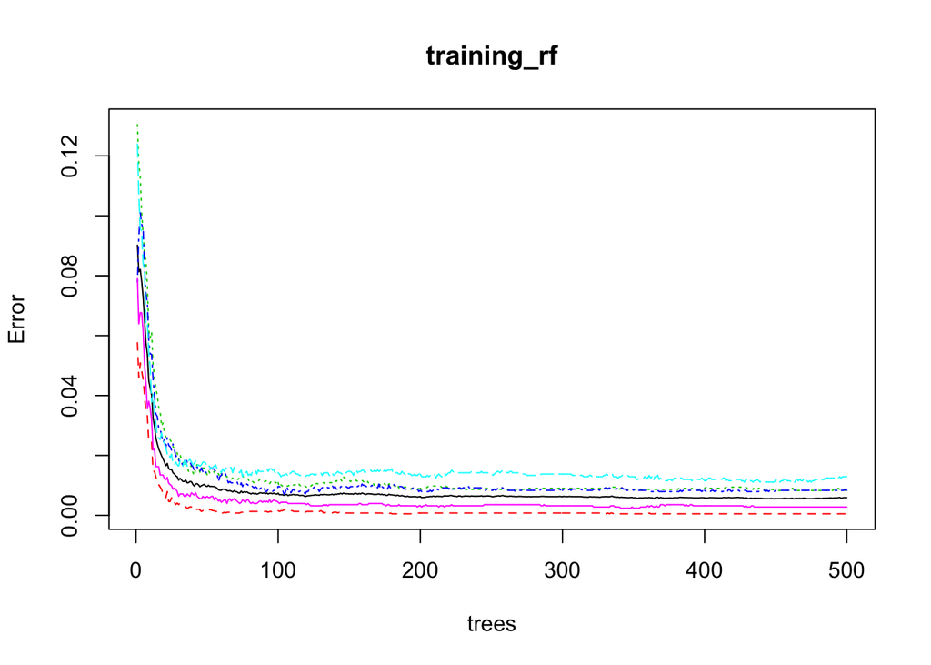

```r
plot(training_rf)
```

## The model is tested on the validation set:

```r
pred<-predict(training_rf,validationset);validationset$predRight<-pred==validationset$classe
confusionMatrix(pred, validationset$classe)
```

```
## Confusion Matrix and Statistics
##
##           Reference
## Prediction    A    B    C    D    E
##          A 1672    5    0    0    0
##          B    1 1133    7    0    0
##          C    0    1 1018    3    0
##          D    0    0    1  961    0
##          E    1    0    0    0 1082
##
## Overall Statistics
##
##                Accuracy : 0.9968
##                  95% CI : (0.995, 0.9981)
##     No Information Rate : 0.2845
##     P-Value [Acc > NIR] : < 2.2e-16
##
##                   Kappa : 0.9959
##  Mcnemar's Test P-Value : NA
##
## Statistics by Class:
##
##                      Class: A Class: B Class: C Class: D Class: E
## Sensitivity            0.9988   0.9947   0.9922   0.9969   1.0000
## Specificity            0.9988   0.9983   0.9992   0.9998   0.9998
## Pos Pred Value         0.9970   0.9930   0.9961   0.9990   0.9991
## Neg Pred Value         0.9995   0.9987   0.9984   0.9994   1.0000
## Prevalence             0.2845   0.1935   0.1743   0.1638   0.1839
## Detection Rate         0.2841   0.1925   0.1730   0.1633   0.1839
## Detection Prevalence   0.2850   0.1939   0.1737   0.1635   0.1840
## Balanced Accuracy      0.9988   0.9965   0.9957   0.9983   0.9999
```

## Use prediction model to predict 20 testcases

```r
pred2<-predict(training_rf,testnew)
pred2
```

```
##  1  2  3  4  5  6  7  8  9 10 11 12 13 14 15 16 17 18 19 20
##  B  A  B  A  A  E  D  B  A  A  B  C  B  A  E  E  A  B  B  B
## Levels: A B C D E
```